# Exploratory Data Analysis using ggplot2

# Introduction

In this practical, you will conduct an exploratory data analysis, to investigate the relationship between portion size and nutritional value of the items sold at McDonald’s. To do this, you will need to use ‘ggplot2’ and ‘tidyverse’, as you did in the previous practical. The dataset used contains information on the McDonald’s menu and can be downloaded [here](https://www.kaggle.com/mcdonalds/nutrition-facts). Save the data as a .csv file in the same folder as the rmd file that you work in.

# Loading the data into R

To load the data from a separate file, use ‘read.cvs()’.

```r
library(tidyverse)
library(GGally)
menu <- read.csv('menu.csv')
```

# A first impression of the data

Before you start the analysis, a good first step is to get a sense of what the dataset looks like. This is especially when you import data from a separate file, because it is of great importance that you check whether the dataset is imported correctly.

```r
# Get an idea of what the menu dataset looks like
head(menu)
```

|  | Category | Item | Serving.Size | Calories | Calories.from.Fat | Total.Fat | Total.Fat....Daily.Value. | Saturated.Fat | Saturated.Fat....Daily.Value. | Trans.Fat | Cholesterol | Cholesterol....Daily.Value. | Sodium | Sodium....Daily.Value. | Carbohydrates | Carbohydrates....Daily.Value. | Dietary.Fiber | Dietary.Fiber....Daily.Value. | Sugars | Protein | Vitamin.A....Daily.Value. | Vitamin.C....Daily.Value. | Calcium....Daily.Value. | Iron....Daily.Value. |
| --- | --- | --- | --- | --- | --- | --- | --- | --- | --- | --- | --- | --- | --- | --- | --- | --- | --- | --- | --- | --- | --- | --- | --- | --- |
| 1 | Breakfast | Egg McMuffin | 4.8 oz (136 g) | 300 | 120 | 13 | 20 | 5 | 25 | 0 | 260 | 87 | 750 | 31 | 31 | 10 | 4 | 17 | 3 | 17 | 10 | 0 | 25 | 15 |
| 2 | Breakfast | Egg White Delight | 4.8 oz (135 g) | 250 | 70 | 8 | 12 | 3 | 15 | 0 | 25 | 8 | 770 | 32 | 30 | 10 | 4 | 17 | 3 | 18 | 6 | 0 | 25 | 8 |
| 3 | Breakfast | Sausage McMuffin | 3.9 oz (111 g) | 370 | 200 | 23 | 35 | 8 | 42 | 0 | 45 | 15 | 780 | 33 | 29 | 10 | 4 | 17 | 2 | 14 | 8 | 0 | 25 | 10 |
| 4 | Breakfast | Sausage McMuffin with Egg | 5.7 oz (161 g) | 450 | 250 | 28 | 43 | 10 | 52 | 0 | 285 | 95 | 860 | 36 | 30 | 10 | 4 | 17 | 2 | 21 | 15 | 0 | 30 | 15 |
| 5 | Breakfast | Sausage McMuffin with Egg Whites | 5.7 oz (161 g) | 400 | 210 | 23 | 35 | 8 | 42 | 0 | 50 | 16 | 880 | 37 | 30 | 10 | 4 | 17 | 2 | 21 | 6 | 0 | 25 | 10 |
| 6 | Breakfast | Steak & Egg McMuffin | 6.5 oz (185 g) | 430 | 210 | 23 | 36 | 9 | 46 | 1 | 300 | 100 | 960 | 40 | 31 | 10 | 4 | 18 | 3 | 26 | 15 | 2 | 30 | 20 |

```r
# Check the structure of the menu dataset
str(menu)
```

```
## 'data.frame':    260 obs. of  24 variables:
##  $ Category                     : Factor w/ 9 levels "Beef & Pork",..: 3 3 3 3 3 3 3 3 3 3 ...
##  $ Item                         : Factor w/ 260 levels "1% Low Fat Milk Jug",..: 76 77 228 229 230 245 12 11 14 13 ...
##  $ Serving.Size                 : Factor w/ 107 levels "1 carton (236 ml)",..: 55 54 42 69 69 83 63 72 65 73 ...
##  $ Calories                     : int  300 250 370 450 400 430 460 520 410 470 ...
##  $ Calories.from.Fat            : int  120 70 200 250 210 210 230 270 180 220 ...
##  $ Total.Fat                    : num  13 8 23 28 23 23 26 30 20 25 ...
##  $ Total.Fat....Daily.Value.    : int  20 12 35 43 35 36 40 47 32 38 ...
##  $ Saturated.Fat                : num  5 3 8 10 8 9 13 14 11 12 ...
##  $ Saturated.Fat....Daily.Value.: int  25 15 42 52 42 46 65 68 56 59 ...
##  $ Trans.Fat                    : num  0 0 0 0 0 1 0 0 0 0 ...
##  $ Cholesterol                  : int  260 25 45 285 50 300 250 250 35 35 ...
##  $ Cholesterol....Daily.Value.  : int  87 8 15 95 16 100 83 83 11 11 ...
##  $ Sodium                       : int  750 770 780 860 880 960 1300 1410 1300 1420 ...
##  $ Sodium....Daily.Value.       : int  31 32 33 36 37 40 54 59 54 59 ...
##  $ Carbohydrates                : int  31 30 29 30 30 31 38 43 36 42 ...
##  $ Carbohydrates....Daily.Value.: int  10 10 10 10 10 10 13 14 12 14 ...
##  $ Dietary.Fiber                : int  4 4 4 4 4 4 2 3 2 3 ...
##  $ Dietary.Fiber....Daily.Value.: int  17 17 17 17 17 18 7 12 7 12 ...
##  $ Sugars                       : int  3 3 2 2 2 3 3 4 3 4 ...
##  $ Protein                      : int  17 18 14 21 21 26 19 19 20 20 ...
##  $ Vitamin.A....Daily.Value.    : int  10 6 8 15 6 15 10 15 2 6 ...
##  $ Vitamin.C....Daily.Value.    : int  0 0 0 0 0 2 8 8 8 8 ...
##  $ Calcium....Daily.Value.      : int  25 25 25 30 25 30 15 20 15 15 ...
##  $ Iron....Daily.Value.         : int  15 8 10 15 10 20 15 20 10 15 ...
```

It can be seen that the variable indicating the serving size is of a vary inconvenient form. To transform this variable into a numeric variable indication the serving size in grams (food) or millilitres (drinks), you can run the code below. You can also try to recode it yourself of course!

```r
# Transformation drinks
drink.fl <- menu %>%
  filter(str_detect(Serving.Size, " fl oz.*")) %>%
  mutate(Serving.Size = str_remove(Serving.Size, " fl oz.*")) %>%
  mutate(Serving.Size = as.numeric(Serving.Size) * 29.5735)

drink.carton <- menu %>%
  filter(str_detect(Serving.Size, "carton")) %>%
  mutate(Serving.Size = str_extract(Serving.Size, "[0-9]{2,3}")) %>%
  mutate(Serving.Size = as.numeric(Serving.Size))

# Transformation food
food <-  menu %>%
  filter(str_detect(Serving.Size, "g")) %>%
  mutate(Serving.Size = (str_extract(Serving.Size, "(?<=\\()[0-9]{2,4}"))) %>%
  mutate(Serving.Size = as.numeric(Serving.Size))

# Add Type variable indicating whether an item is food or a drink
menu2 <-  bind_rows(drink.fl, drink.carton, food) %>%
  mutate(
   Type = case_when(
     as.character(Category) == 'Beverages' ~ 'Drinks',
     as.character(Category) == 'Coffee & Tea' ~ 'Drinks',
     as.character(Category) == 'Smoothies & Shakes' ~ 'Drinks',
     TRUE ~ 'Food'
   )
  )
```

1. **After you ran the code, check the structure of the data once again, what type of variable is ‘Serving.Size’ now, and what was it before you ran the code?**

```r
# The variable type of Serving.Size is numeric, before running the code it was a factor variable with 107 factors.
```

# Variation

The first type of questions in visual EDA concern the variation in the data. As you can see, the items are categorized into different product groups. To get an idea of the variation among item categories and nutritional value, several visualisations can be made.

2. **Create a graph that gives insight in the number of items in each ‘Category’, use ‘geom_bar()’ to make the graph. You can use ‘coord_flip()’ to put the categories on the y-axis and the counts on the x-axis. Use the ‘menu2’ dataframe to do this.**

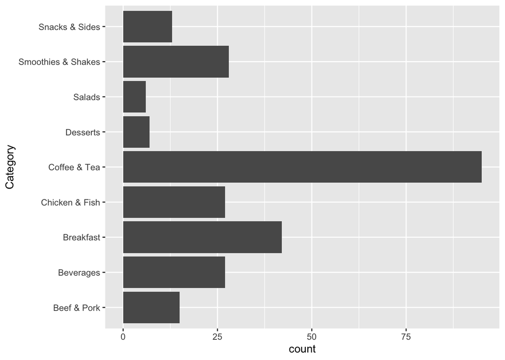

```r
ggplot(data = menu2) +
  geom_bar(mapping = aes(x = Category)) +
  coord_flip()
```

3. **Plot the distribution of ‘Calories’ using ‘geom_histogram’. Describe the distribution, do you see anything notable?**

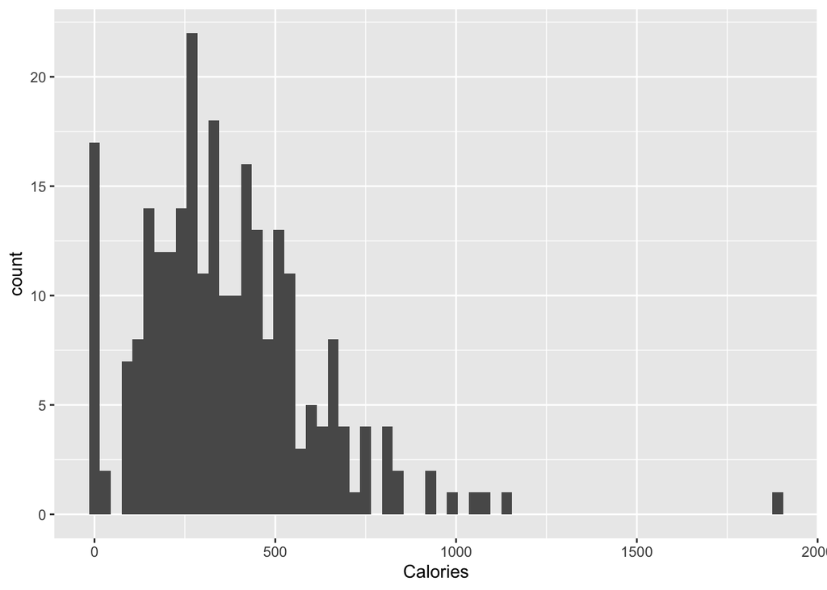

```r
ggplot(data = menu2) +
  geom_histogram(mapping = aes(x = Calories), binwidth = 30)
```

```r
# The distribution is slightly skewed to the right, most items contain less than 750 calories.
# There is one outlier containing almost 2000 calories.
```

# Association

The second type of questions in visual EDA concern the association between different variables. The histogram you created in the previous question give insight in how the ‘Calories’ are distributed on the level of the whole menu. However, it may be interesting how ‘Calories’ are distributed on ‘Category’ level.

4. **Plot the distribution of ‘Calories’ for each ‘Category’ using ‘geom_density()’ in combination with ‘facet_wrap()’, can you see in which ‘Category’ the outlier that can be seen in the histogram falls?**

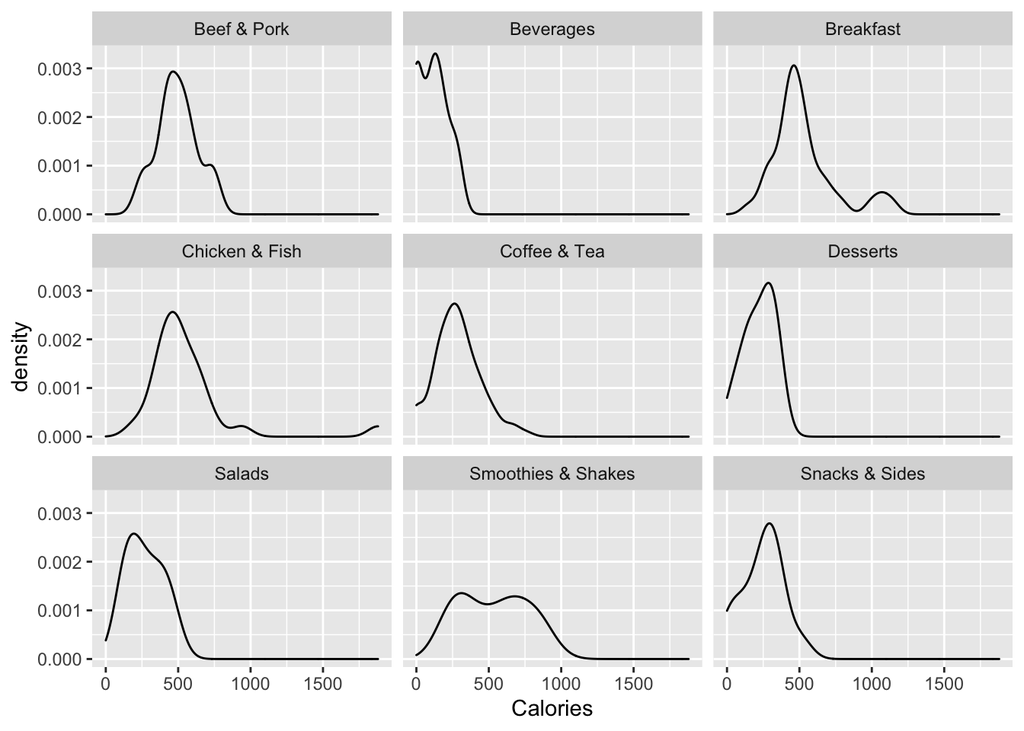

```r
ggplot(data = menu2) +
  geom_density(mapping = aes(x = Calories)) +
  facet_wrap(~Category)
```

```r
# The Chicken & Fish density plot shows a little bump at the end, the outlier of almost 2000 calories is a Chicken & Fish item.
```

An easier way to spot outliers, is by creating a boxplot, because the geom is structured in a way that it emphasizes the outliers.

5. **Create a boxplot of the ‘Calories’ for each ‘Category. Is the outlier in the same ’Category’ as you thought it was in based on the previous question?‘. Again you can use ’coord_flip()’ to swich the axes of the plot.**

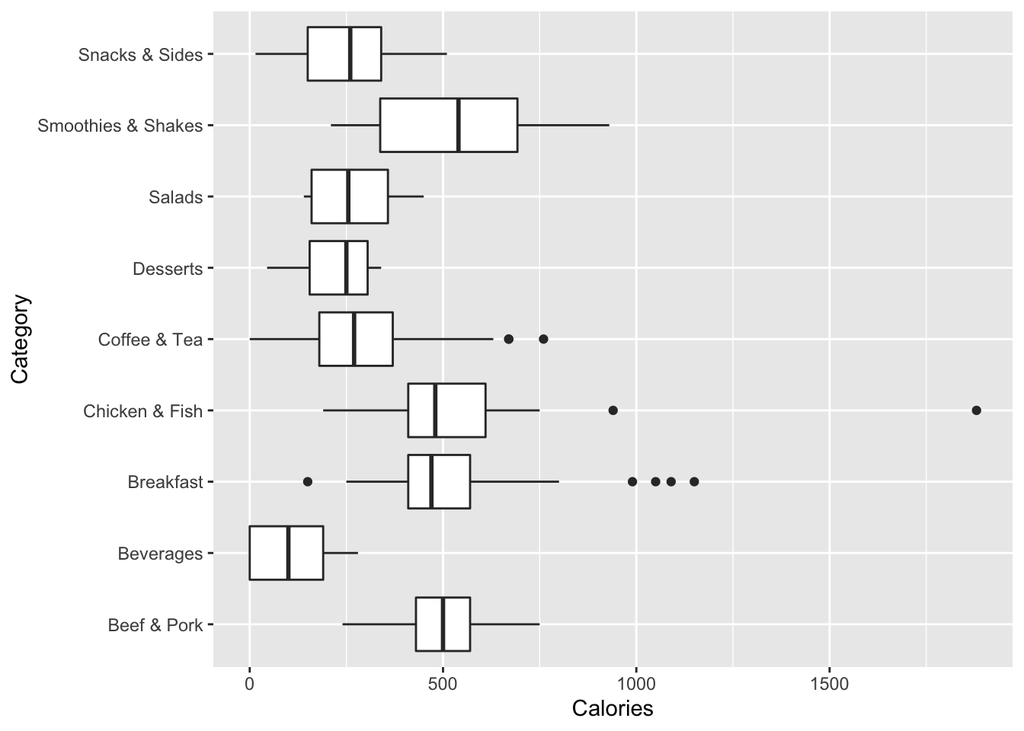

```r
ggplot(data = menu2) +
  geom_boxplot(mapping = aes (x = Category, y = Calories)) +
  coord_flip()
```

```r
# Yes, very easy to see now that the outlier is in the Chicken & Fish category.
```

Now you know in which category the outlier falls, you can check which item it is that has such a high energetic value.

For the next plot, you need to pipe the data using ‘%>%’ from the ‘magrittr’ package. More information on piping can be found [here](https://r4ds.had.co.nz/pipes.html).

6. **Create a plot using ‘geom_col()’ to visualise the number of ‘Calories’ each item in the Chicken & Fish category. Use ‘filter()’ in combination with a pipe to select the information that you need for this plot. What is the item that contains so many calories? Why do you need to use ‘geom_col()’ here instead of ‘geom_bar()’?**

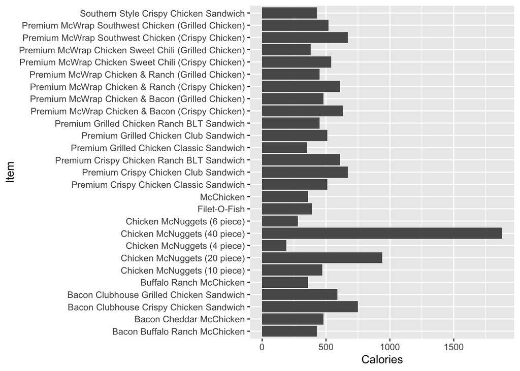

```r
menu2 %>%
  filter(Category == "Chicken & Fish") %>%
    ggplot(mapping = aes(x = Item, y = Calories)) +
    geom_col() +
    coord_flip()
```

```r
# The item containing the stunning amount of almost 2000 calories is the 40 piece Chicken McNuggets.
# Geom_bar() makes the height of the bar proportional to the number of cases in each category, geom_col() uses values in the data to determine the height of the bars. Since in this plot, the height of the bars should indicate the energetic value (calories), geom_col() should be used. See ?geom_bar() for more info.
```

Now you know what causes the outlier, you can check whether there is an association between the serving size and the number of calories.

7. **Create a scatter plot to visualise the association between serving size and calories. Are serving size and energetic value related to each other? Did you expect this outcome? Use the alpha argument in geom_point() to adjust the transparency.**

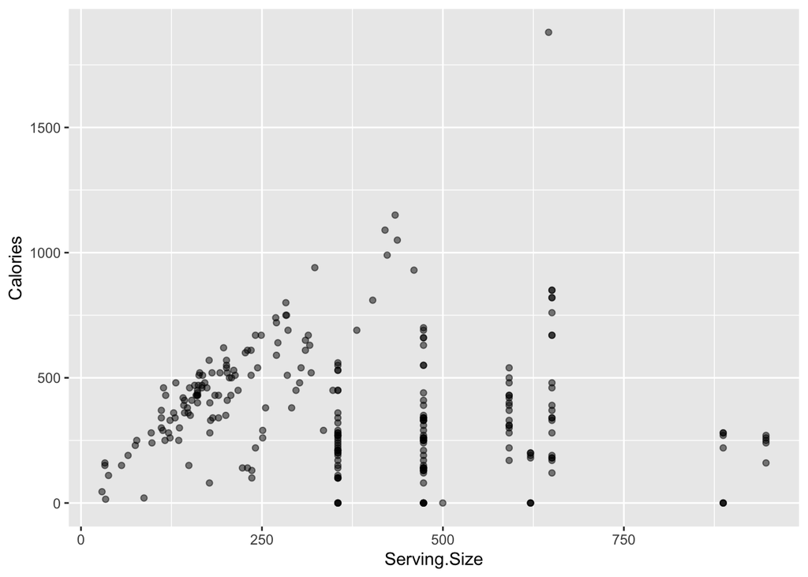

```r
ggplot(data = menu2, mapping= aes(x = Serving.Size, y = Calories)) +
  geom_point(alpha = 0.5)
```

```r
# There doesn't seem to be a strong relationship between the portion size and energetic value based on this plot. However, this seems highly counter intuitive since you'd expect that the larger the portion, the more calories it contains.
```

8. **Create a new scatter plot to visualise the association between serving size and calories, but now use the ‘colour’ argument to make a distinction between ‘Type’ (see ?aes for more info). Use ‘geom_smooth()’ to add a regression line to the plot. Does this alter your conclusion about the relationship between serving size and calories? What do you conclude now?**

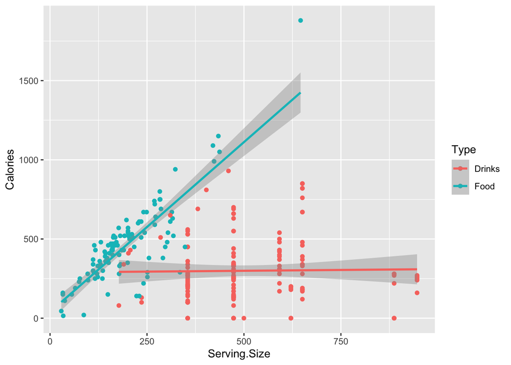

```r
ggplot(data = menu2, mapping = aes(x = Serving.Size, y = Calories, colour = Type)) +
  geom_point() +
  geom_smooth(method = 'lm')
```

```r
# When splitting up the data in drinks and food, you see that there is actually a very strong relation between serving size and calories for the food items, where the association is very weak for the drink items.
```

9. **Why do you think the relationship is so much affected by food type, is there a way to investigate this further using visualisations?**

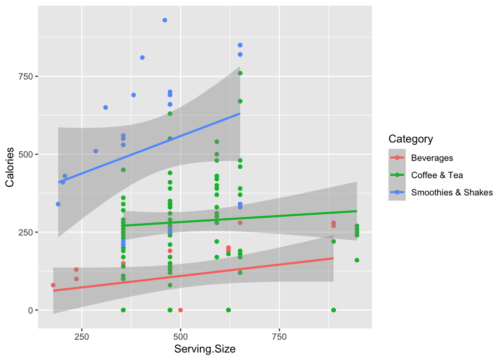

```r
# A part of the drink-type items are items with no calories at all (coffee/tea, light sodas), so for these items the correlation between calories and serving size is zero. This items are likely to deflate the correlation for drink-type items a lot. A way of investigating this hypothesis using a visualisation is this:

menu2 %>%
  filter(Type == 'Drinks') %>%
    ggplot(mapping = aes(x = Serving.Size, y = Calories, colour = Category)) +
    geom_point() +
    geom_smooth(method = 'lm')
```

```r
# As can be seen from the plot, the association between categories containing 0 calory items (Beverages and Coffee& Tea) is far weaker than the category wihout 0 calory items (Smoothies & Shakes)
```

So far, you’ve only looked at the association between two variables at a time. However, when you are exploring associations, you may want to look at the association of many different variables at the same time (e.g. when you want to generate hypotheses). An easy way to do this, is to make use of the ‘ggpairs()’ function from the ‘GGally’ package.

10. **Create a plot using ‘ggpairs()’ where the association between atleast 4 different variables is visualised. Are there differences in the associations between those variables based on item Type?**

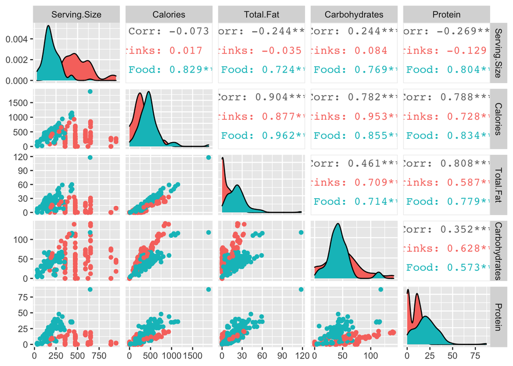

```r
# In this plot, the association between Serving.Size, Calories and the three macro nutritients are visualised. Becuase GGally is an extension of ggplot2, additional aesthetics arguments can be added to make a distinction in type.

ggpairs(menu2, columns = c('Serving.Size', 'Calories', 'Total.Fat', 'Carbohydrates', 'Protein'), ggplot2::aes(colour = Type))
```

```r
# Using this plot, you can see that the correlations change a lot when you take into account the item type. This phenomenon, where the correlation disappears or even changes of direction when taking groups into account, is called the Simpson's paradox.
```